# Lab 03 - EDA and Viz 1

JSC370 (Winter 2026)

Published

January 21, 2026

# Learning Goals

- Download [lab 3 here](https://github.com/JSC370/JSC370-2026/blob/main/labs/lab3/lab03-github.qmd)
- Read in from github and get familiar with a meteorology dataset
- Plan out how to tackle the objective question
- Step through the EDA “checklist” presented in the class slides
- Make exploratory graphs and maps

# Deliverables

- Complete the code and summaries and upload your .qmd and rendered .html to Quercus

# Lab Description

We will work with similar meteorological data that was presented in lecture. Recall the dataset consists of weather station readings in the contiguous US.

**The objective of the lab is to find the weather station with the lowest elevation, find out where this location is (make a map), and make a time series plot of temperature at this station.**

# Steps

### 0. Load libraries

Notes:

- import the necessary libraries
- note setting pandas options for nicer display of the output
- in the yaml above set enabled to true when you want the code to render

```python
import pandas as pd
pd.set_option("display.float_format", "{:.2f}".format)
import numpy as np
import matplotlib.pyplot as plt
import geopandas as gpd
import contextily as cx
from IPython.display import display
```

### 1. Read in the data

Connect to github and read in data with pandas.

```python
url = "https://raw.githubusercontent.com/JSC370/JSC370-2026/main/data/met_all_2025.gz"
met = pd.read_csv(url, compression="gzip")
met.head(4)
```

|  | USAFID | WBAN | year | month | day | hour | min | lat | lon | elev | ... | vis_dist_qc | vis_var | vis_var_qc | temp | temp_qc | dew_point | dew_point_qc | atm_press | atm_press_qc | rh |
| --- | --- | --- | --- | --- | --- | --- | --- | --- | --- | --- | --- | --- | --- | --- | --- | --- | --- | --- | --- | --- | --- |
| 0 | 690150 | 93121 | 2025 | 6 | 1 | 0 | 26 | 34.30 | -116.16 | 625 | ... | 1 | 9 | 9 | 37.20 | 1 | 4.40 | 1 | NaN | 9 | 12.95 |
| 1 | 690150 | 93121 | 2025 | 6 | 1 | 0 | 54 | 34.30 | -116.16 | 625 | ... | 1 | 9 | 9 | 36.70 | 1 | 4.40 | 1 | 1008.40 | 1 | 13.32 |
| 2 | 690150 | 93121 | 2025 | 6 | 1 | 1 | 54 | 34.30 | -116.16 | 625 | ... | 1 | 9 | 9 | 34.40 | 1 | 4.40 | 1 | 1008.40 | 1 | 15.19 |
| 3 | 690150 | 93121 | 2025 | 6 | 1 | 2 | 54 | 34.30 | -116.16 | 625 | ... | 1 | 9 | 9 | 32.20 | 1 | 5.60 | 1 | 1008.90 | 1 | 18.77 |

4 rows × 30 columns

### 2. Check the memory size, dataset dimensions, and the header. How many columns, rows are there?

- fill in where there are …

```python
met.memory_usage(deep=True).sum() / 1024 ** 3
```

```
np.float64(2.46077074483037)
```

```python
print("shape:", met.shape)
print("n_rows:", met.shape[0])
print("n_cols:", met.shape[1])
```

```
shape: (5381580, 30)
n_rows: 5381580
n_cols: 30
```

```python
met.head
```

```
<bound method NDFrame.head of          USAFID   WBAN  year  month  day  hour  min   lat     lon  elev  ...  \
0        690150  93121  2025      6    1     0   26 34.30 -116.16   625  ...
1        690150  93121  2025      6    1     0   54 34.30 -116.16   625  ...
2        690150  93121  2025      6    1     1   54 34.30 -116.16   625  ...
3        690150  93121  2025      6    1     2   54 34.30 -116.16   625  ...
4        690150  93121  2025      6    1     3   54 34.30 -116.16   625  ...
...         ...    ...   ...    ...  ...   ...  ...   ...     ...   ...  ...
5381575  749486    397  2025      7   31    22   35 39.22 -121.00   961  ...
5381576  749486    397  2025      7   31    22   55 39.22 -121.00   961  ...
5381577  749486    397  2025      7   31    23   15 39.22 -121.00   961  ...
5381578  749486    397  2025      7   31    23   35 39.22 -121.00   961  ...
5381579  749486    397  2025      7   31    23   55 39.22 -121.00   961  ...

         vis_dist_qc  vis_var vis_var_qc  temp  temp_qc  dew_point  \
0                  1        9          9 37.20        1       4.40
```

[output cut: 25 more lines]

Summary: - add bullets with your summary

- The total memory used by the DataFrame is 2.46GB approximately.
- There are 5381580 rows and 30 columns.
- There are a lot of variables which are similar to the example provided in the lecture.

### 3. Look at data types of the variables in the dataset.

```python
met.dtypes
```

```
USAFID                 int64
WBAN                   int64
year                   int64
month                  int64
day                    int64
hour                   int64
min                    int64
lat                  float64
lon                  float64
elev                   int64
wind_dir             float64
wind_dir_qc            int64
wind_type_code        object
wind_sp              float64
wind_sp_qc             int64
ceiling_ht           float64
ceiling_ht_qc          int64
ceiling_ht_method     object
sky_cond              object
vis_dist             float64
vis_dist_qc            int64
vis_var               object
vis_var_qc             int64
temp                 float64
temp_qc               object
dew_point            float64
dew_point_qc          object
atm_press            float64
atm_press_qc           int64
rh                   float64
dtype: object
```

Summary: - add bullets with your summary

- The data types of the variables in the dataset are either integers, floats, or objects.

### 4. Take a closer look at the key variables (`temp` and `elev`).

- Are there missing data in these variables? If so, make sure they are coded correctly.

```python
key_vars = ['temp', 'elev']

met[key_vars].isnull().sum()
```

```
temp    0
elev    0
dtype: int64
```

- Are there any unusual values that look suspicious?

```python
minT = met['temp'].min()
maxT = met['temp'].max()

minE = met['elev'].min()
maxE = met['elev'].max()

print(minT, maxT, minE, maxE)
```

```
-40.0 999.9 -35 3680
```

Summary:

- There are no missing values in either `temp` or `elev` variables (both show 0 null values).
- Temperature ranges from -40.0°C to 999.9°C. The maximum value of 999.9°C is highly suspicious and likely represents a missing data code or measurement error, as this temperature is physically impossible.
- Elevation ranges from -35 meters to 3680 meters. The minimum elevation of -35m is plausible (below sea level locations exist in the US, such as Death Valley), and the maximum of 3680m is reasonable for high-altitude weather stations.

### 5. Check the data against an external data source and make any other adjustments.

- Check that the range of elevations make sense. Google or ChatGPT is your friend here.
- Fix any problems that arise in your checks.

```python
met.loc[met['temp'] > 60, 'temp'] = np.nan
met[['temp']].describe().round(4)
```

|  | temp |
| --- | --- |
| count | 5196576.00 |
| mean | 23.71 |
| std | 6.05 |
| min | -40.00 |
| 25% | 20.00 |
| 50% | 24.00 |
| 75% | 28.00 |
| max | 56.00 |

Summary:

- Removed implausible temperature values above 60°C (such as the 999.9°C value identified earlier) by setting them to NaN.
- After cleaning, the temperature now ranges from -40.0°C to 56.0°C, which are both physically plausible for weather stations in the US.
- The mean temperature is 23.71°C with a standard deviation of 6.05°C.
- The temperature distribution appears reasonable, with the median (24°C) close to the mean, suggesting a roughly symmetric distribution.

```python
cold_temps = met[met['temp'] < -20]

# display data here extract lat and lon and check google
cold_temps[['USAFID', 'temp', 'lat', 'lon', 'elev']].head(10)
```

|  | USAFID | temp | lat | lon | elev |
| --- | --- | --- | --- | --- | --- |
| 1015246 | 720742 | -24.00 | 28.21 | -100.02 | 236 |
| 1015247 | 720742 | -23.00 | 28.21 | -100.02 | 236 |
| 1015249 | 720742 | -30.00 | 28.21 | -100.02 | 236 |
| 1015253 | 720742 | -34.00 | 28.21 | -100.02 | 236 |
| 1015310 | 720742 | -32.00 | 28.21 | -100.02 | 236 |
| 1015312 | 720742 | -32.00 | 28.21 | -100.02 | 236 |
| 1015313 | 720742 | -37.00 | 28.21 | -100.02 | 236 |
| 1015383 | 720742 | -40.00 | 28.21 | -100.02 | 236 |
| 1015598 | 720742 | -34.00 | 28.21 | -100.02 | 236 |
| 1015600 | 720742 | -40.00 | 28.21 | -100.02 | 236 |

Summary: - I’ve extracted the latitude and longitude of the weather stations with temperatures below -20°C. - I’ve found that the majority of the data is provided by the station with lat 28.21 and lon -100.02. This station is located at the boarder of United States and Mexico in Texas. It does not seems to make sense to me that the temperature is so low in this area (like -20°C to -40°C). - Also, there are several observations that the temperature is below -20°C at the station with lat 29.84 and lon -82.05.01. This station is located in Florida. It does not seems to make sense to me that the temperature is so low in this area (-20°C to -40°C).

```python
# Fix up data here, remove implausible values
# Remove extremely cold temperatures only from warm-climate locations (Texas and Florida)
# based on the suspicious stations identified above
met.loc[(met['temp'] < -20) & (met['USAFID'].isin([720742, 749048])), 'temp'] = np.nan

# Verify the cleaning
print("Temperature range after cleaning:")
print(f"Min: {met['temp'].min()}, Max: {met['temp'].max()}")
print(f"\nNumber of observations with temp < -20 remaining: {(met['temp'] < -20).sum()}")
```

```
Temperature range after cleaning:
Min: -20.0, Max: 56.0

Number of observations with temp < -20 remaining: 0
```

## 6. Answer research questions

Remember to keep the initial questions in mind. We want to pick out the weather station with minimum elevation and examine its temperature.

Some ideas for steps: 1. subset the data for the weather station with minimum elevation 2. look at histograms of temperature 3. make a time series plot (need to create date variable) 4. make a map to see where it is

### 6a. Subset minimum elevation site

```python
# Subset data for the weather station with minimum elevation
# First filter to only use data with valid temperatures (> -20°C)
met_filtered = met[met['temp'] > -20].copy()

min_elevation = met_filtered['elev'].min()
print(f"Minimum elevation: {min_elevation} meters")

min_elev_station = met_filtered[met_filtered['elev'] == min_elevation].copy()

print(f"Number of observations at minimum elevation station: {len(min_elev_station)}")
print(f"Station USAFID: {min_elev_station['USAFID'].unique()}")
```

```
Minimum elevation: -35 meters
Number of observations at minimum elevation station: 1437
Station USAFID: [747187]
```

### 6b. Histogram of temperature at minimum elevation site

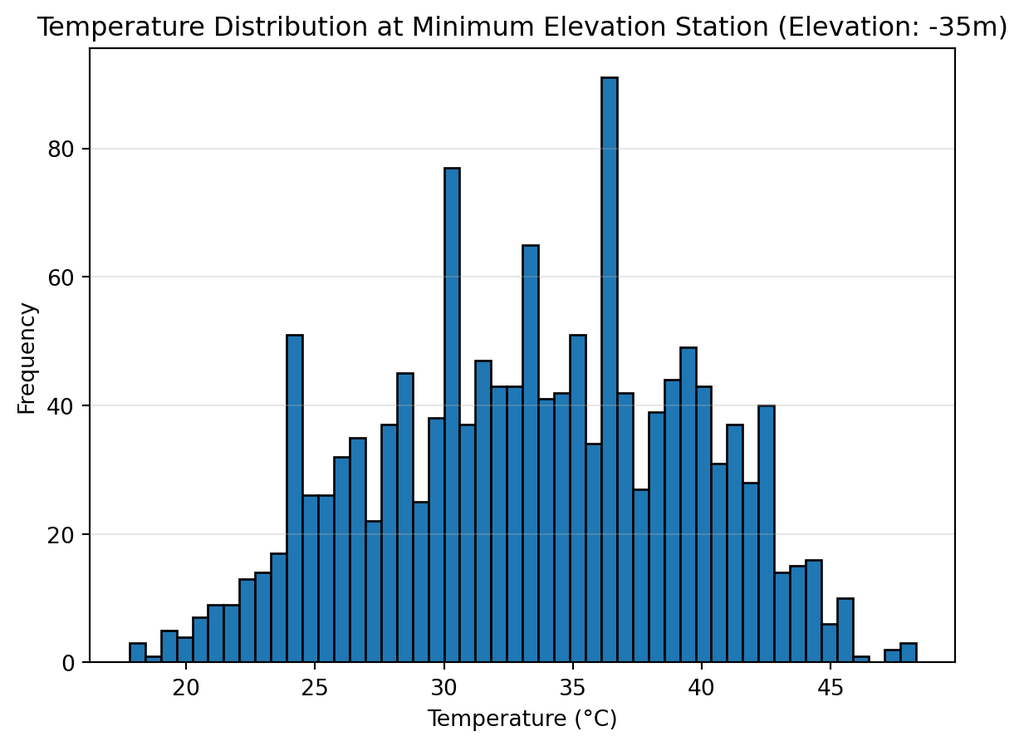

```python
plt.hist(min_elev_station['temp'].dropna(), bins=50, edgecolor='black')
plt.xlabel('Temperature (°C)')
plt.ylabel('Frequency')
plt.title(f'Temperature Distribution at Minimum Elevation Station (Elevation: {min_elevation}m)')
plt.grid(axis='y', alpha=0.3)
plt.show()
```

### 6c. Create date variable and time series plot

- Look at the time series of temperature at this location. For this we will need to create a date-time variable for the x-axis.
- Summarize any trends that you see in these time series plots.

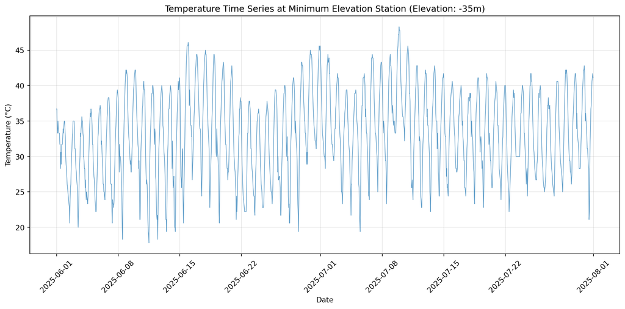

```python
# Create a date variable for min_elev_station
min_elev_station = min_elev_station.copy()
min_elev_station['date'] = pd.to_datetime(
    min_elev_station[['year', 'month', 'day', 'hour']]
)

# Sort by date
min_elev_station = min_elev_station.sort_values('date')

# Create line plot of temperature by date
plt.figure(figsize=(12, 6))
plt.plot(min_elev_station['date'], min_elev_station['temp'], linewidth=0.8, alpha=0.7)
plt.xlabel('Date')
plt.ylabel('Temperature (°C)')
plt.title(f'Temperature Time Series at Minimum Elevation Station (Elevation: {min_elevation}m)')
plt.grid(True, alpha=0.3)
plt.xticks(rotation=45)
plt.tight_layout()
plt.show()
```

### 6d. Where is the lowest weather station?

```
Lowest elevation station details:
USAFID: 747187
Latitude: 33.632, Longitude: -116.164
Elevation: -35 m
```

[figure not shown]

```python
station_location = min_elev_station[['lat', 'lon', 'elev', 'USAFID']].drop_duplicates()

lat = station_location['lat'].iloc[0]
lon = station_location['lon'].iloc[0]
elev = station_location['elev'].iloc[0]
usafid = station_location['USAFID'].iloc[0]

print(f"Lowest elevation station details:")
print(f"USAFID: {usafid}")
print(f"Latitude: {lat}, Longitude: {lon}")
print(f"Elevation: {elev} m")

gdf = gpd.GeoDataFrame(
    {'elevation': [elev]},
    geometry=gpd.points_from_xy([lon], [lat]),
    crs='EPSG:4326'
)

gdf = gdf.to_crs('EPSG:3857')

fig, ax = plt.subplots(figsize=(10, 8))
gdf.plot(ax=ax, color='red', markersize=300, marker='*', edgecolor='black', linewidth=2, zorder=5)
cx.add_basemap(ax, source=cx.providers.OpenStreetMap.Mapnik)
ax.set_xlabel('Longitude')
ax.set_ylabel('Latitude')
ax.set_title(f'Lowest Elevation Station (Elevation: {elev} m)')
plt.show()
```